# Code for figures and models

## Reading the data

The code chunk below pulls in the numbers from the EXCEL file. The variable names are the long form of the questions - so, below, I created a couple of shorter variable names to work with in document.

```r
data<- read_excel("C:\\Users\\Nana Ama\\Desktop\\Trials\\Rstudio\\surveyer.xlsx")
```

### Measuring Water Service Satisfaction

The survey data from 2020 includes eight questions related to water service:

Two questions were recoded below so that the highest number is satisfied or strongly agree:

How often did you receive water? (original coding:1=Never…4=Always) (n~300) Is provincial delivery equitable across municipalities? (original coding: 1 strongly agree, 4 strongly disagree, 5 is Don’t Know (125))

New variables: water access 1=Never…4=Always water equity: 1=strongly disagree…..4=strongly agree

Not used: Do you have water? (1=Yes, 2=No) Who provides your water? (1=Government,2=Privately provided, 3= Self-provided) Do you pay for water? (1=Yes,2=No) If “YES”, how much do you pay per month?(Insert amount in kwanzas) Where does the household get drinking water from? (1… 13)

```r
# eight questions related to water access:

#Do you have water? (1=Yes, 2=No)
# How often did you receive water? (original coding:1=Never...4=Always) (n~300)
#Who provides your water? (1=Government,2=Privately provided, 3= Self-provided)
#Do you pay for water?(1=Yes, 2=No)
# Is provincial delivery equitable across municipalities? (1 strongly agree, 4 strongly disagree, 5 is Don't Know (125))
#If “YES”, how much do you pay per month?   (Insert amount in kwanzas)
#Where does the household get drinking water from? (1......13)
# Is water access one of "the most important problems that this country faces that the government should resolve?"  (46/531 mention) (recoded to dummy 0=no 1=mentioned)


# Recodes 5-response so 4 becomes 1 and 1 becomes 4...
data <-data %>%
 mutate(water_access=5-data$`57)If “YES”, how often per week?(Read out options)`,
        water_equity=5-data$`84) Do you agree or disagree with the statement: Over president dos Santos post-civil war period, that is, from 2002 to 2017, your provincial government delivered water across municipalities regardless of political affiliation? (Read out options)`,
         water_problem=data$`87) Water ( In your opinion, what are the most important problems that this country faces that the government should resolve? (Write up to 3 problems))`
        )
data <- data %>%
  mutate(problem.dummy = if_else(data$water_problem==8, 1, 0, 0))
```

The code chunk below recodes or identifies the variables:

- ethnicity
- province
- party
- neighborhood is central city or slum

```r
# Ethnicity
# Province
# Party
# Neighborhood - to construct urban vs. other

data$ethnicity<-data$`88) What is your ethnic group?`

data$party<-data$`90) If “YES”, which party is that?`
# Note that most of these are missing - respondent doesn't feel close to a party.

# I make the party a factor - meaning labels rather than numbers - are the labels attached to the correct numbers? 1=MPLA 2=UNITA, 7=some other party names...the number in parentheses is the number of people picking that party.
data$party<- factor(data$party,
levels = c(1,2,3,4,5,7), ordered=FALSE,
labels = c("MPLA (136)", "UNITA (46)", "CASE-CE (14)", "PRS (6)", "FNLA (4)", "Other (32)"))

# Province is available (5 provinces, already factor)
data$Province<-factor(data$Province, levels = c("Luanda", "Bengo", "Benguela", "Lunda Norte", "Malanje"))

# Central city vs slum
data<- data %>% mutate(slum=recode(Neigborhood,
                                   "Centralidade do 44"=0,
                                   "Sanzala Grande" = 1,
                                   "Desvio" = 1,
                                   "Estação 44"=1,
                                   "Centralidade de Capari" =0,
                                   "Musseque Capari" = 1,
                                   "Musseque kikoca" =1,
                                   "Centralidade do Lobito" =0,
                                   "Lixeira"=1,
                                   "4 de Fevereiro"=1,
                                   "Downtown"= 0,
                                   "Centro da cidade"=0 ,
                                   "Cangambo ocidental"=0,
                                   "Bela fama"=1,
                                   "Camoma"=1,
                                   "Cafuco-fuco"=1,
                                   "Carreira de tiro"=1,
                                   "Centralidade do Mussungue"=0,
                                   "Samacaca"=0,
                                   "Estufa"=1,
                                   "Camaquenzo 2"=1,
                                   "Caita"=1))
```

### Service delivery: core compared to slums

The figures below measures satisfaction with water services, comparing residents of slums to other urban residents - based on how satisfied people are with water services received. (Higher scores indicate more satisfied)

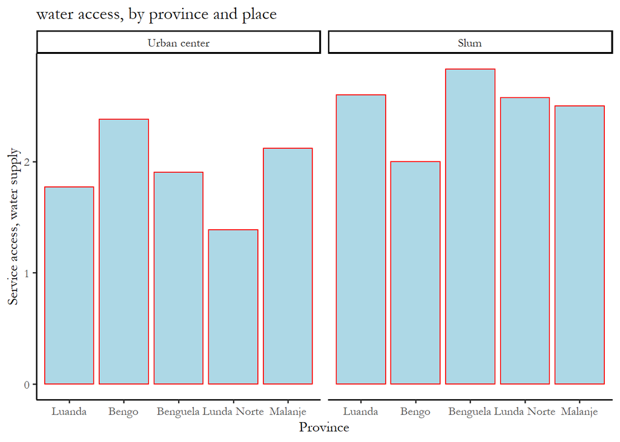

```r
# Facet labels
place_names <- as_labeller(     c(`0` = "Urban center", `1` = "Slum"))
# The names above are used in the "facet_wrap" below
# if you delete the facet_wrap line you just get one plot by province

# This is the command to make the plot
ggplot (data, aes(x=Province, y=water_access))+
  geom_bar(stat = "summary", fun = "mean", fill="lightblue", color="red") +
  ylab("Service access, water supply")+
  xlab("Province")+
  facet_wrap(data$slum, labeller=place_names) +
  ggtitle("water access, by province and place")
```

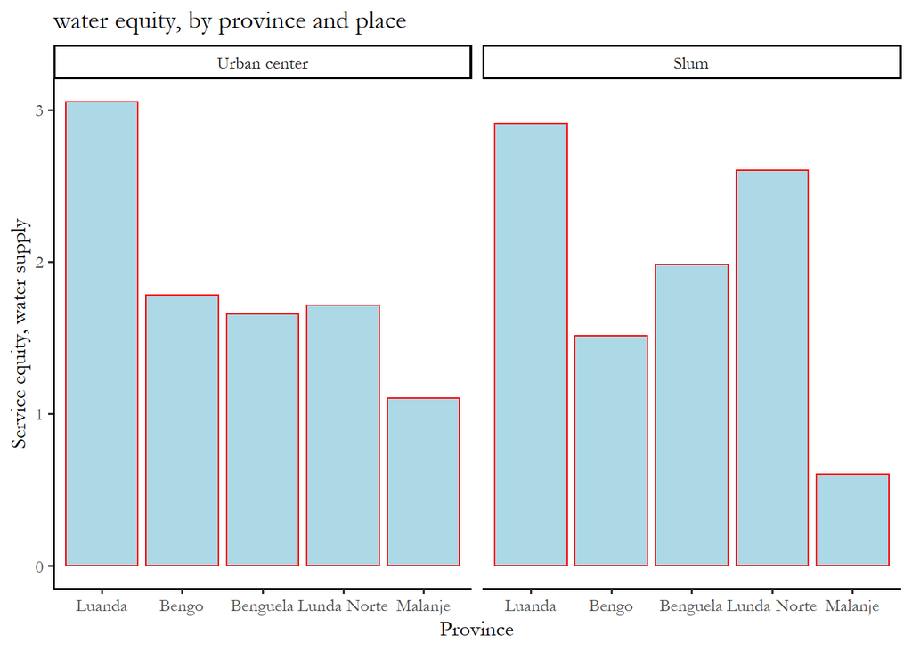

```r
ggplot (data, aes(x=Province, y=water_equity))+
  geom_bar(stat = "summary", fun = "mean", fill="lightblue", color="red") +
  ylab("Service equity, water supply")+
  xlab("Province")+
  facet_wrap(data$slum, labeller=place_names) +
  ggtitle("water equity, by province and place")
```

### Service delivery and province

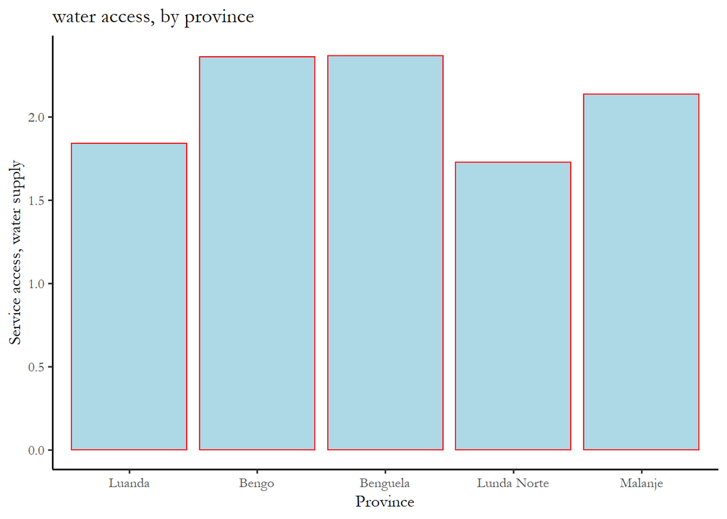

```r
ggplot (data, aes(x=Province, y=water_access))+
  geom_bar(stat = "summary", fun = "mean", fill="lightblue", color="red") +
  ylab("Service access, water supply")+
  xlab("Province")+
  ggtitle("water access, by province")
```

## Service delivery and political affiliation

The factor labels show the party name and number of people who are in that party in the sample. NA means no party preference given.

There doesn’t seem to be any meaningful variation.

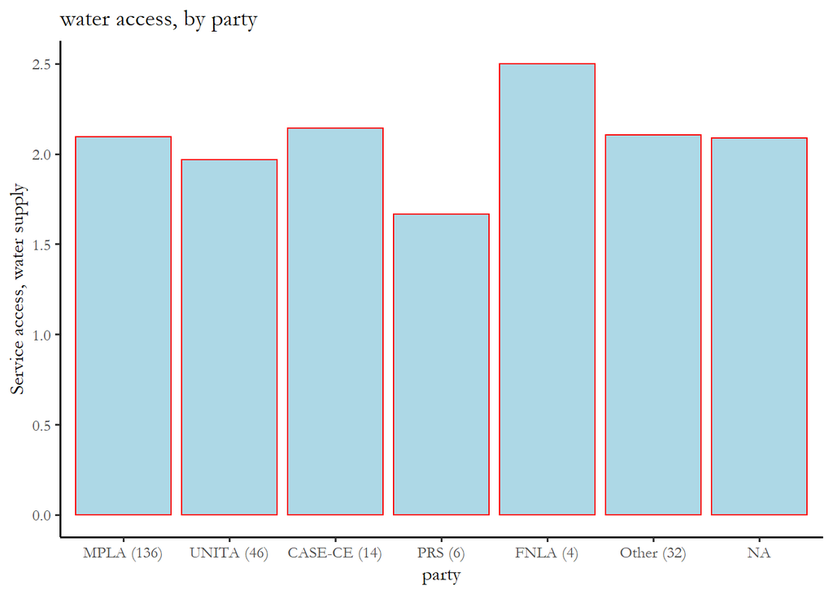

```r
ggplot (data, aes(x=party, y=water_access))+
  geom_bar(stat = "summary", fun = "mean", fill="lightblue", color="red") +
  ylab("Service access, water supply")+
  xlab("party")+
  ggtitle("water access, by party")
```

## Models to confirm

The model just uses the political party, slum vs central, and province, jointly, to estimate impacts on satisfaction

negative coefficients in the first table indicate lower levels of satisfaction.

The baseline categories for party is the MPLA and the baseline category for province is Luanda

```r
model1<-lm(water_access~party+Province+slum, data=data)
model2<-lm(water_equity~party+Province+slum, data=data)
stargazer(model1, model2, type="text", style="apsr")
```

```
-------------------------------------------------------------------
                         water_access            water_equity
                             (1)                     (2)
-------------------------------------------------------------------
partyUNITA (46)             -0.067                  0.102
                           (0.182)                 (0.184)
partyCASE-CE (14)           -0.011                  0.110
                           (0.321)                 (0.294)
partyPRS (6)                -0.364                  -0.709
                           (0.474)                 (0.437)
partyFNLA (4)               0.025                   -0.022
                           (0.571)                 (0.529)
partyOther (32)             -0.124                  0.106
                           (0.217)                 (0.211)
ProvinceBengo               0.373*                -1.500***
                           (0.220)                 (0.230)
ProvinceBenguela            -0.118                -1.319***
                           (0.235)                 (0.252)
ProvinceLunda Norte         -0.248                -0.725***
                           (0.208)                 (0.205)
ProvinceMalanje             0.038                 -2.028***
                           (0.199)                 (0.193)
slum                       0.803***                 -0.098
                           (0.214)                 (0.142)
Constant                   2.010***                3.033***
                           (0.156)                 (0.165)
N                            144                     238
R2                          0.131                   0.370
Adjusted R2                 0.066                   0.343
Residual Std. Error    0.781 (df = 133)        1.023 (df = 227)
F Statistic         2.008** (df = 10; 133) 13.350*** (df = 10; 227)
-------------------------------------------------------------------
*p < .1; **p < .05; ***p < .01
```